# Vital Signs Stats - PhysioNet Sepsis Challenge

efg | 2019-04-01

> An expanded training database is now available, containing data from a total of 40,336 subjects. The complete training database (42 MB), consisting of two parts: training set A (20,336 subjects) and B (20,000 subjects).

# 1 Purpose

The purpose of this notebook is to take a preliminary look at the raw data from 40,336 patients in the PhysioNet 2019 challenge, where some had sepsis and some did not.

The focus of this notebook is on the **Vital Signs** data (**columns 1 - 8**) and the outcome (column 41)

- `SepsisLabel`. For sepsis patients, `SepsisLabel` is 1 if $t \ge t_{sepsis} - 6$ and 0 if $t < t_{sepsis} - 6$. For non-sepsis patients, `SepsisLabel` is 0.

# 2 Background

The data being analyzed is from the [Early Prediction of Sepsis from Clinical Data: the PhysioNet/Computing in Cardiology Challenge 2019](https://physionet.org/challenge/2019/).

# 3 Exploration

## 3.1 Setup

```r
plotCaptionLeft  <- "Source:  PhysioNet 2019 Sepsis Project"
plotCaptionRight <- paste("efg", format(Sys.time(), "%Y-%m-%d"))
```

### 3.1.1 Packages

```r
library(tidyverse)
library(kableExtra) # kable_styling
library(readxl)
library(gridExtra)
library(grid)
```

### 3.1.2 Helper function

```r
Show <- function(data, caption="", bigMark="")
{
  data                                          %>%
  kable("html",
        caption=caption,
        format.args = list(big.mark=bigMark))   %>%
  kable_styling(bootstrap_options = c("striped", "bordered", "condensed"),
                position = "left", full_width = FALSE)
}
```

### 3.1.3 Vital Signs List and Units

From file Vital-Signs.xlsx

| Quantity | Units | Description |
| --- | --- | --- |
| HR | beats per minute | Heart rate |
| O2Sat | % | Pulse oximetry |
| Temp | deg C | Temperature |
| SBP | mm Hg | Systolic blood pressure |
| MAP | mm Hg | Mean arterial pressure |
| DBP | mm Hg | Diastolic blood pressure |
| Resp | breaths per minute | Respiration Rate |
| EtCO2 | mm Hg | End tidal carbon dioxide |

### 3.1.4 Load PhysioNet 2019 Challenge Combined Data

```r
load(file = "../../data/PhysioNet-2019-Raw-Data-A.RData")
dim(allDataA)
```

```
[1] 790215     42
```

```r
load(file = "../../data/PhysioNet-2019-Raw-Data-B.RData")
dim(allDataB)
```

```
[1] 761995     42
```

Combine A and B

```r
allData <- bind_rows(allDataA, allDataB)
dim(allData)
```

```
## [1] 1552210      42
```

Verify vital signs match

```r
all(vitalSigns$Quantity %in% names(allData))
```

```
[1] TRUE
```

Sample Vital Signs

```r
allData                                           %>%
  select( patient, ICULOS,
          vitalSigns$Quantity,
          SepsisLabel)                            %>%
  head()                                          %>%
  Show()
```

| patient | ICULOS | HR | O2Sat | Temp | SBP | MAP | DBP | Resp | EtCO2 | SepsisLabel |
| --- | --- | --- | --- | --- | --- | --- | --- | --- | --- | --- |
| p000001 | 1 | NA | NA | NA | NA | NA | NA | NA | NA | 0 |
| p000001 | 2 | 97 | 95.0 | NA | 98 | 75.33 | NA | 19.0 | NA | 0 |
| p000001 | 3 | 89 | 99.0 | NA | 122 | 86.00 | NA | 22.0 | NA | 0 |
| p000001 | 4 | 90 | 95.0 | NA | NA | NA | NA | 30.0 | NA | 0 |
| p000001 | 5 | 103 | 88.5 | NA | 122 | 91.33 | NA | 24.5 | NA | 0 |
| p000001 | 6 | 110 | 91.0 | NA | NA | NA | NA | 22.0 | NA | 0 |

## 3.2 Sepsis Label

```r
table(allData$SepsisLabel, useNA = "ifany")
```

```
      0       1
1524294   27916
```

## 3.3 Vital Signs

```r
for (i in 1:nrow(vitalSigns))
{
  cat("\n###", paste(vitalSigns$Quantity[i], " - ",
                     vitalSigns$Description[i]), "\n")

  rawData <-
    allData                                      %>%
    select(vitalSigns$Quantity[i], SepsisLabel)  %>%
    na.omit()                                    %>%
    mutate(Sepsis = recode(SepsisLabel,
                           "0" = "Not Sepsis",
                           "1" = "Sepsis"))      %>%
    mutate(Sepsis = as.factor(Sepsis))

  valueBoxplot <-
    ggplot(rawData,
           aes_string("Sepsis",
                      vitalSigns$Quantity[i],
                      fill = "Sepsis"))                      +
    geom_boxplot(notch = TRUE)                               +
    scale_x_discrete(labels = paste(c("Not Sepsis", "Sepsis"),
                                    paste0("n = ",
                                           table(rawData$Sepsis)) ,
                                    sep = "\n") ) +
    labs(title = paste(vitalSigns$Quantity[i], " - ",
                       vitalSigns$Description[i]),
         x = "",
         y = paste0(vitalSigns$Quantity[i],
                          "[", vitalSigns$Units[i], "]"))    +
    scale_fill_brewer(palette = "Pastel1", direction = -1)   +
    theme(legend.position = "none",
          plot.margin = unit(c(5, 5, 5, 12), "mm"))          +
    coord_flip()

  valueDensity <-
    ggplot(rawData, aes_string(x = vitalSigns$Quantity[i]))  +
    geom_density(aes_string(group = "Sepsis", fill = "Sepsis"),
                 alpha = 0.5)   +
    labs(x = paste0(vitalSigns$Quantity[i],
                          "[", vitalSigns$Units[i], "]"),
         caption = c(plotCaptionLeft, plotCaptionRight))     +
    scale_fill_brewer(palette = "Pastel1", direction = -1)   +
    theme(plot.caption = element_text(hjust = c(0, 1)),
          legend.position = "none",
          plot.margin = unit(c(5, 5, 5, 20), "mm"))

  grid.arrange(valueBoxplot, valueDensity)

  cat("\n")
}
```

### 3.3.1 HR - Heart rate

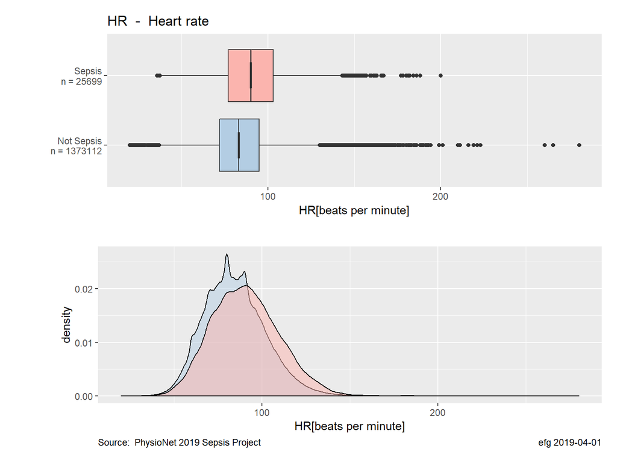

### 3.3.2 O2Sat - Pulse oximetry

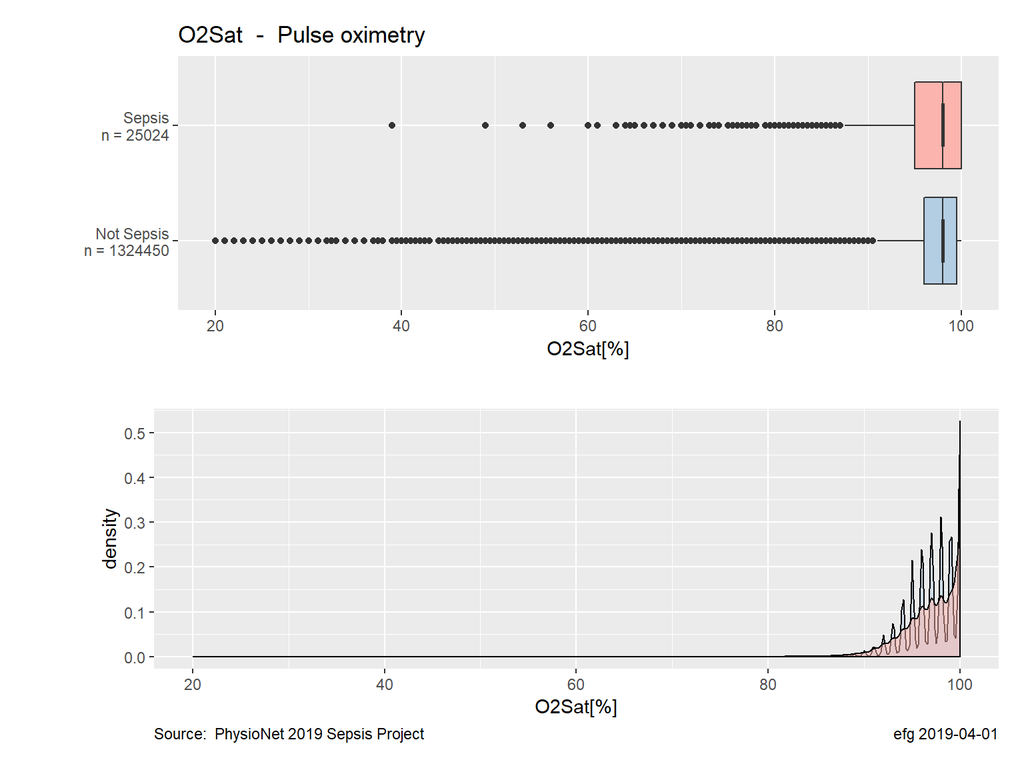

### 3.3.3 Temp - Temperature

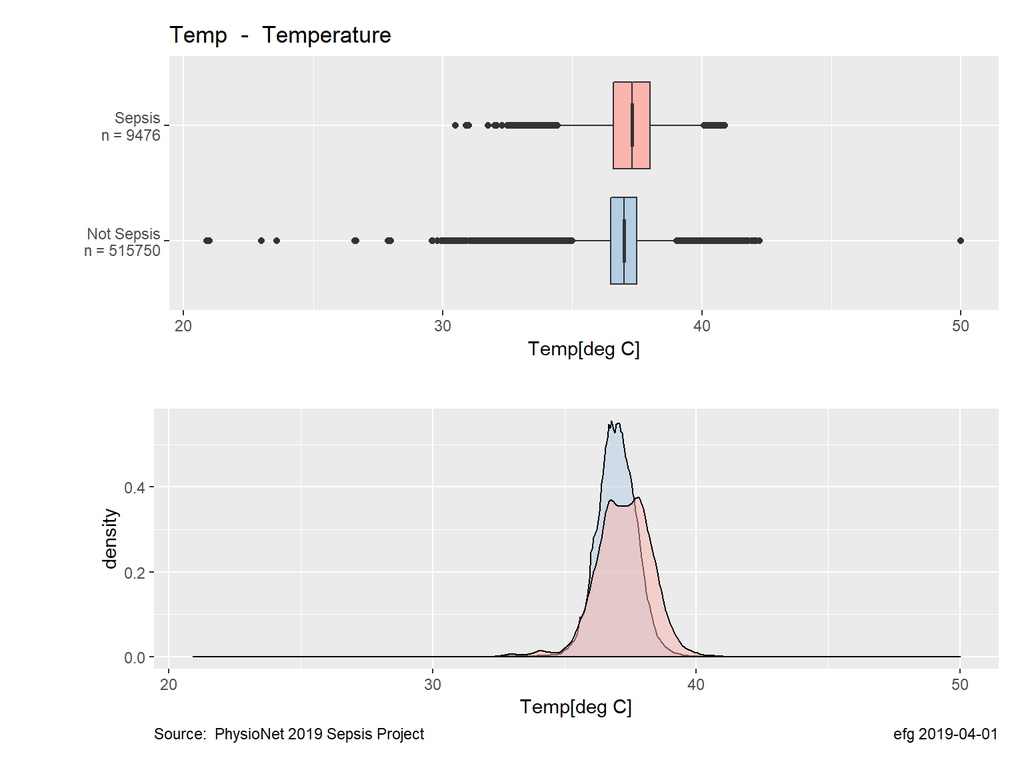

### 3.3.4 SBP - Systolic blood pressure

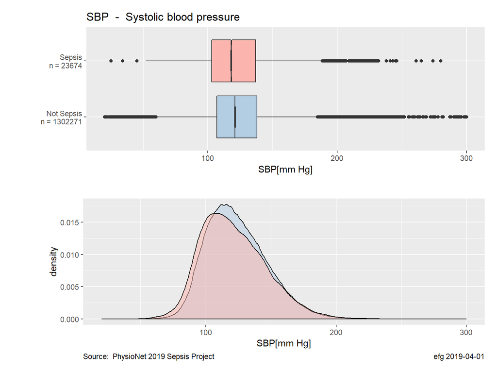

### 3.3.5 MAP - Mean arterial pressure

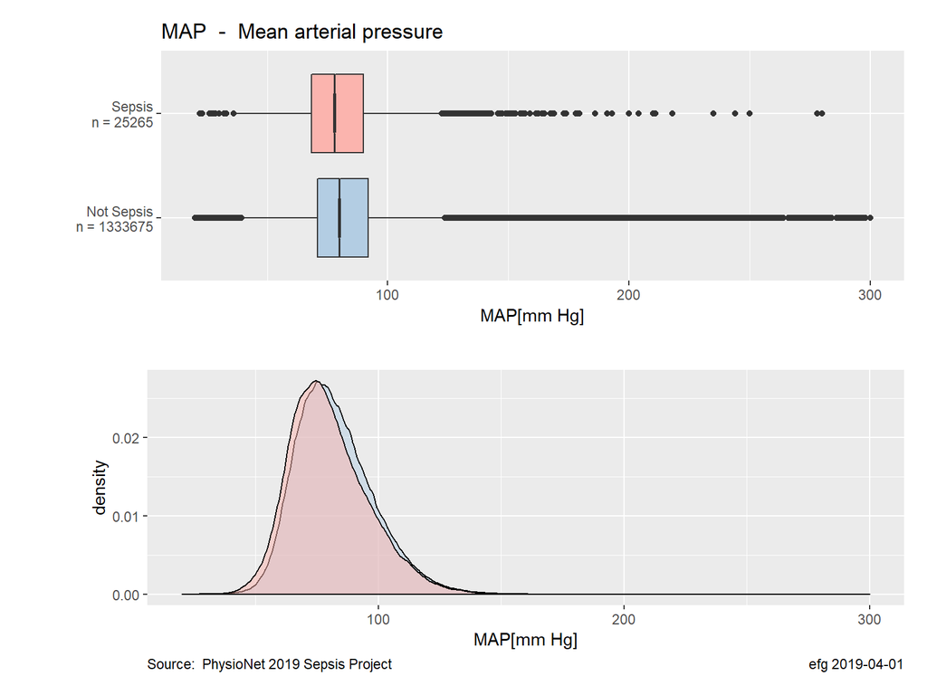

### 3.3.6 DBP - Diastolic blood pressure

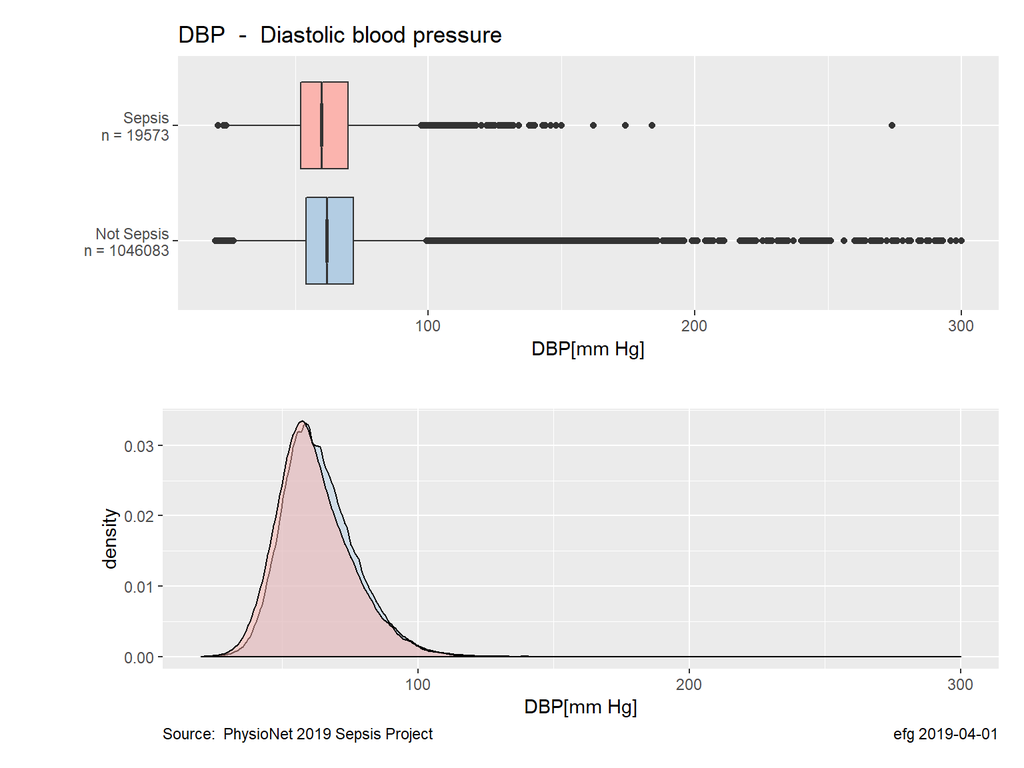

### 3.3.7 Resp - Respiration Rate

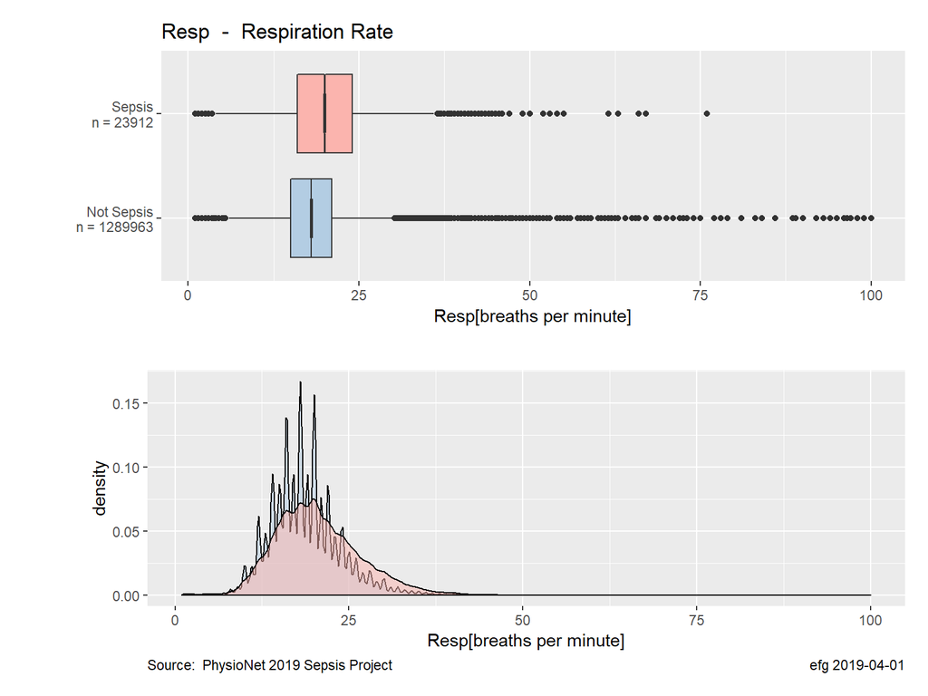

### 3.3.8 EtCO2 - End tidal carbon dioxide

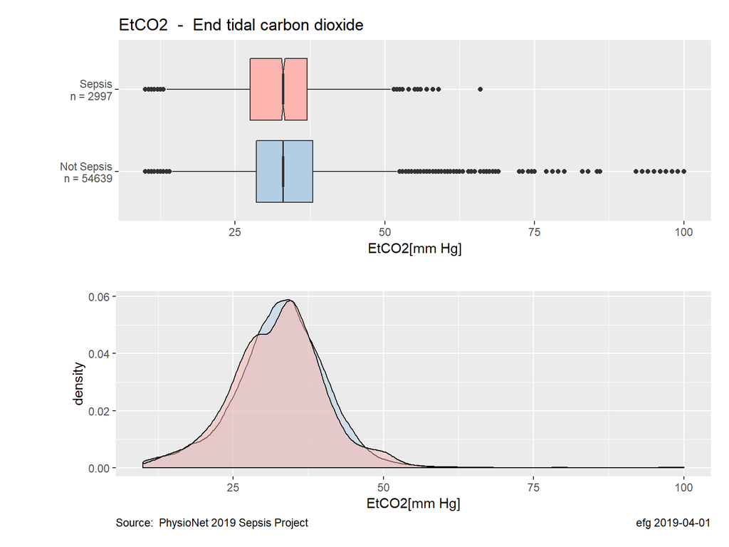

# 4 Discussion

[work in progress]

# 5 Conclusions

[work in progress]

Processing time: 46.9 secs

2019-04-01 2257